# Econ 320: Python Assignment 2

## Simple Regression and Summary Stats

```python
# import libraries
import pandas as pd
import numpy as np
import matplotlib.pyplot as plt
import seaborn as sns
import statsmodels.formula.api as smf
# change decimal places to 3
pd.set_option('display.float_format', lambda x: '%.3f' % x)
```

## Question 1

In this exercise we will be interested in study the relationship between average earnings and education levels, using the data set from the 1992 and 2008 Current Population Survey (CPS). Specifically, we want to see whether the average hourly earnings (`ahe`) are different between workers with a bachelor degree and those with only high school diploma (`bachelor`). Use the data provided in Canvas to respond the following questions.

a. How many observations are in this data set?

```python
# read data
#df = pd.read_excel('cps92_08.xlsx', index_col=0)
#df.head()
#df.describe()
#df.info()
```

```python
df = pd.read_excel('cps92_08.xlsx')
df.head()
df.describe()
print(df)
```

```
       year    ahe  bachelor  female  age
0      1992 11.189         1       0   29
1      1992 10.000         1       0   33
2      1992  5.769         0       0   30
3      1992  1.562         0       0   32
4      1992 14.957         1       0   31
...     ...    ...       ...     ...  ...
15311  2008 12.500         0       0   32
15312  2008 24.725         1       1   28
15313  2008 41.209         1       0   33
15314  2008  3.269         1       1   31
15315  2008 13.269         0       0   30

[15316 rows x 5 columns]
```

There are 15316 observations

b. Compute the sample mean for average hourly earnings (`ahe`) in 1992 and in 2008.

```python
# your code goes here
ahe_1992 = df[df['year'] == 1992]['ahe'].mean()
ahe_2008 = df[df['year'] == 2008]['ahe'].mean()
print(f'{ahe_1992}')
print(f'{ahe_2008}')
```

```
11.626365163889
18.97609235893782
```

c. In order to make a right comparison between the values of earning in 2008 and 1992, we should adjust adjust the average hourly earnings in the 1992 dollars to the 2008 dollars with the inflation rate, computed as

$$\frac{CPI_{2008}}{CPI_{1992}}$$

Consider that those values are equal to 140.3 for 1992 and 215.2 for 2008. Repeat the item above consering this adjusted value for 1992.

```python
# Define the CPI values for 1992 and 2008
cpi_92 = 140.3
cpi_08 = 215.2

# Calculate the inflation adjustment factor
inflator = cpi_08 / cpi_92

# Apply inflation adjustment to the 'ahe' column
df.loc[df['year'] == 1992, 'ahe'] = df.loc[df['year'] == 1992, 'ahe'] * inflator
# your answer goes here
print(df)
```

```
       year    ahe  bachelor  female  age
0      1992 17.162         1       0   29
1      1992 15.339         1       0   33
2      1992  8.849         0       0   30
3      1992  2.397         0       0   32
4      1992 22.942         1       0   31
...     ...    ...       ...     ...  ...
15311  2008 12.500         0       0   32
15312  2008 24.725         1       1   28
15313  2008 41.209         1       0   33
15314  2008  3.269         1       1   31
15315  2008 13.269         0       0   30

[15316 rows x 5 columns]
```

d. Compare in a table how many female students has bachelor degree 1992 vs 2008?

```python
bach_92 = df[(df['year'] == 1992) & (df['female'] == 1) & (df['bachelor'] == 1)].shape[0]
bach_08 = df[(df['year'] == 2008) & (df['female'] == 1) & (df['bachelor'] == 1)].shape[0]


bach_table = pd.DataFrame({ 'Year': ['1992', '2008'],'Female Students with Bachelor\'s': [bach_92, bach_08]})

print(bach_table)
```

```
   Year  Female Students with Bachelor's
0  1992                             1368
1  2008                             1871
```

e. Create 2 boxplot to compare the distribution of average hourly earnings between high school graduates and college graduates for 1992 and 2008, respectively. What can you say about these two graphs? the distributios are changed between these 2 years?

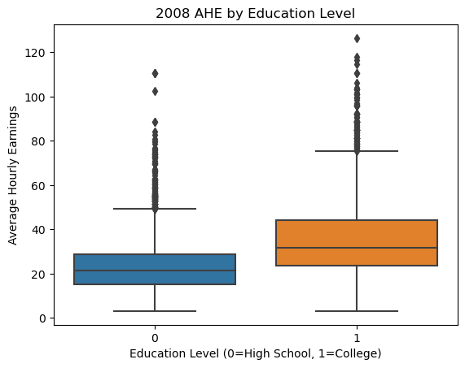

```python
# Select data for the year 2008
cps08 = df[df['year'] == 2008][['year', 'ahe', 'bachelor']]

# Create a boxplot using seaborn
sns.boxplot(x='bachelor', y='ahe', data=cps08)
plt.title('2008 AHE by Education Level')
plt.xlabel('Education Level (0=High School, 1=College)')
plt.ylabel('Average Hourly Earnings')
# your code goes here
```

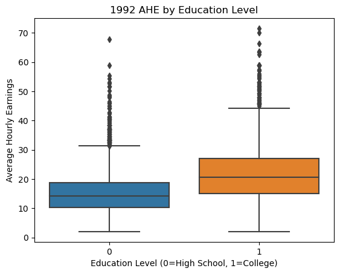

```python
# do the same for the year 1992
cps92 = df[df['year'] == 1992][['year', 'ahe', 'bachelor']]
sns.boxplot(x='bachelor', y='ahe', data=cps92)
plt.title('1992 AHE by Education Level')
plt.xlabel('Education Level (0=High School, 1=College)')
plt.ylabel('Average Hourly Earnings')
```

## Question 2

Using the same dataset CPS92_08, respond the following questions. In this exercise, the relationship between a worker's age and his or her wage income will be investigated. (Generally, older workers have more work experience, which leads to higher productivity and income).

a. Make a scatter plot of AHE (average hourly earnings adjusted) vs. age, add a regression line to it. Does the graph suggest any relationship between the two?

*Hint: See our handout for the graph with a regression line added to it.*

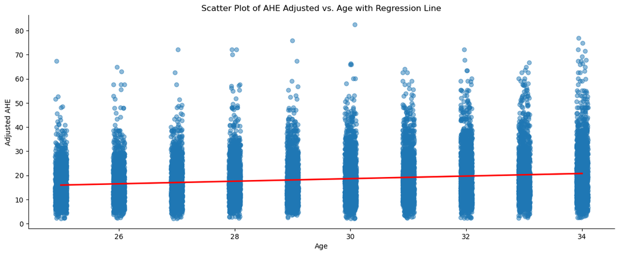

```python
# your code goes here
sns.lmplot(x='age', y='ahe', data=df, x_jitter = 0.1, aspect=2.5, scatter_kws={'alpha':0.5}, line_kws={'color': 'red'})
plt.title('Scatter Plot of AHE Adjusted vs. Age with Regression Line')
plt.xlabel('Age')
plt.ylabel('Adjusted AHE')
plt.show()
```

b. Make a scatter plot of the AHE vs Female. Does the graph suggest any relationship between the two?

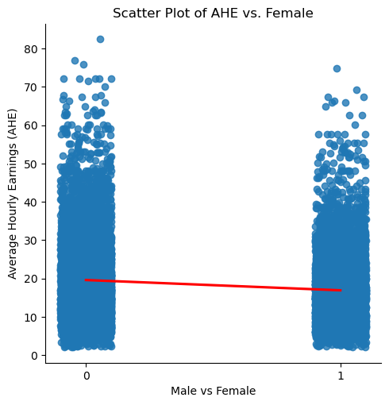

```python
# your code goes here
sns.lmplot(x='female', y='ahe', x_jitter = 0.1, data=df,line_kws={'color': 'red'})
plt.xticks([0, 1])
plt.title('Scatter Plot of AHE vs. Female')
plt.xlabel('Male vs Female')
plt.ylabel('Average Hourly Earnings (AHE)')
plt.show()
```

Men have a slightly higher AHE than women

c. Repeat graphs a)-b), but use $ln(ahe\_adj)$. How do your answers change when using the logarithm?

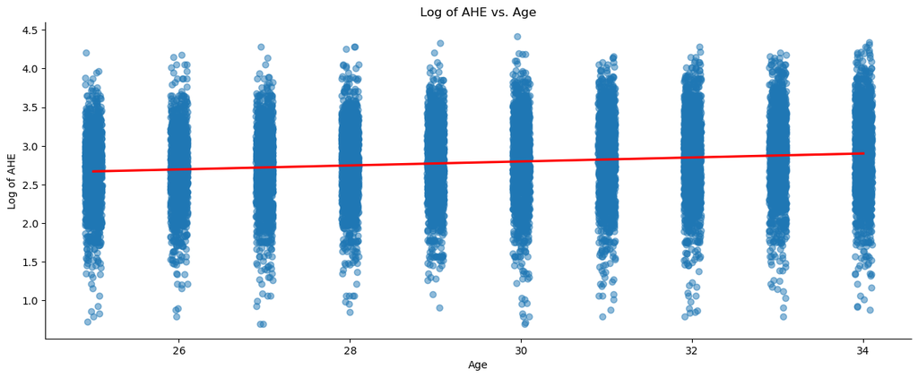

```python
# your code goes here
df['ln_ahe'] = np.log(df['ahe'])

# Replotting with log-transformed AHE
sns.lmplot(x='age', y='ln_ahe', data=df,  x_jitter = 0.1, aspect=2.5, scatter_kws={'alpha':0.5},line_kws={'color': 'red'})
plt.title('Log of AHE vs. Age')
plt.xlabel('Age')
plt.ylabel('Log of AHE')
plt.show()
```

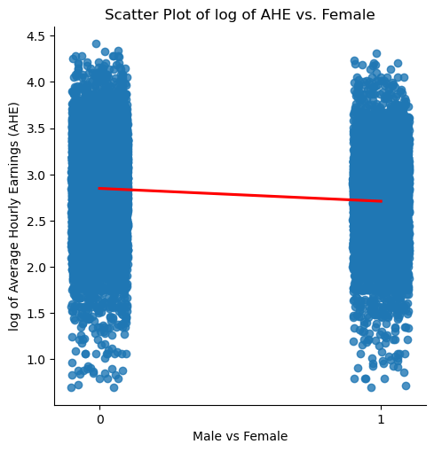

```python
# your code goes here
sns.lmplot(x='female', y='ln_ahe', data=df, x_jitter=0.1, line_kws={'color': 'red'})
plt.xticks([0, 1])
plt.title('Scatter Plot of log of AHE vs. Female')
plt.xlabel('Male vs Female')
plt.ylabel('log of Average Hourly Earnings (AHE)')
plt.show()
```

Only the y-axis changes. But the linear regression lines for all of the graphs are still similar.

```python
# your code goes here
estimate = smf.ols('ln_ahe ~ age', data=df)
result = estimate.fit()
#print(f'estimate.summary(): \n{estimate.summary()}\n')
result.summary()
```

OLS Regression Results

| Dep. Variable: | ln_ahe | R-squared: | 0.021 |
| --- | --- | --- | --- |
| Model: | OLS | Adj. R-squared: | 0.021 |
| Method: | Least Squares | F-statistic: | 322.3 |
| Date: | Thu, 03 Oct 2024 | Prob (F-statistic): | 2.40e-71 |
| Time: | 20:45:06 | Log-Likelihood: | -11200. |
| No. Observations: | 15316 | AIC: | 2.240e+04 |
| Df Residuals: | 15314 | BIC: | 2.242e+04 |
| Df Model: | 1 |  |  |
| Covariance Type: | nonrobust |  |  |

|  | coef | std err | t | P>\|t\| | [0.025 | 0.975] |
| --- | --- | --- | --- | --- | --- | --- |
| Intercept | 2.0253 | 0.043 | 47.407 | 0.000 | 1.942 | 2.109 |
| age | 0.0258 | 0.001 | 17.954 | 0.000 | 0.023 | 0.029 |

| Omnibus: | 340.211 | Durbin-Watson: | 1.736 |
| --- | --- | --- | --- |
| Prob(Omnibus): | 0.000 | Jarque-Bera (JB): | 396.321 |
| Skew: | -0.320 | Prob(JB): | 8.71e-87 |
| Kurtosis: | 3.460 | Cond. No. | 313. |

Notes:  
[1] Standard Errors assume that the covariance matrix of the errors is correctly specified.

To sum up, this is saying that for each additional year of age, the natural log of average hourly wage increases by 0.0258

e. Run a regression between the logarithm of average hourly earnings, `ln(AHE_adj)`, and `age`. In this item you are allowed to use `ols()` command from `statsmodels`. What is your interpretation of your results?

```python
# your code goes here
```

[output not shown]

**THE CALIFORNIA TEST SCORE DATA SET**

See the documentation about the California Test dataset

- Take a look at the variables in this data set
- Choose two variables a Y dependent and an X independent variable for which you could run a regression. Please explain why you chose these two variables and your intuition about their relationship. (Positive or negative and why.)
- Show the correlation coefficient of these two variables.
- Show a graph plotting the relationship between these two.
- Write your regression equation
- Estimate your regression, show and interpret your results. Are these what you were expecting.?
- TRY YOUR BEST TO DO THIS WITHOUT THE HELP OF AI, FOLLOW STEPS FROM HANDOUTS

```python
df1 = pd.read_stata('caschool13.dta')
df1.describe()
```

|  | observation_number | dist_cod | enrl_tot | teachers | calw_pct | meal_pct | computer | testscr | comp_stu | expn_stu | str | avginc | el_pct | read_scr | math_scr |
| --- | --- | --- | --- | --- | --- | --- | --- | --- | --- | --- | --- | --- | --- | --- | --- |
| count | 420.000 | 420.000 | 420.000 | 420.000 | 420.000 | 420.000 | 420.000 | 420.000 | 420.000 | 420.000 | 420.000 | 420.000 | 420.000 | 420.000 | 420.000 |
| mean | 210.500 | 67472.812 | 2628.793 | 129.067 | 13.246 | 44.705 | 303.383 | 654.157 | 0.136 | 5312.407 | 19.640 | 15.317 | 15.768 | 654.970 | 653.343 |
| std | 121.388 | 3466.994 | 3913.107 | 187.913 | 11.455 | 27.123 | 441.341 | 19.053 | 0.065 | 633.937 | 1.892 | 7.226 | 18.286 | 20.108 | 18.754 |
| min | 1.000 | 61382.000 | 81.000 | 4.850 | 0.000 | 0.000 | 0.000 | 605.550 | 0.000 | 3926.070 | 14.000 | 5.335 | 0.000 | 604.500 | 605.400 |
| 25% | 105.750 | 64307.750 | 379.000 | 19.662 | 4.395 | 23.282 | 46.000 | 640.050 | 0.094 | 4906.180 | 18.582 | 10.639 | 1.941 | 640.400 | 639.375 |
| 50% | 210.500 | 67760.500 | 950.500 | 48.565 | 10.520 | 41.751 | 117.500 | 654.450 | 0.125 | 5214.517 | 19.723 | 13.728 | 8.778 | 655.750 | 652.450 |
| 75% | 315.250 | 70419.000 | 3008.000 | 146.350 | 18.981 | 66.865 | 375.250 | 666.663 | 0.164 | 5601.401 | 20.872 | 17.629 | 22.970 | 668.725 | 665.850 |
| max | 420.000 | 75440.000 | 27176.000 | 1429.000 | 78.994 | 100.000 | 3324.000 | 706.750 | 0.421 | 7711.507 | 25.800 | 55.328 | 85.540 | 704.000 | 709.500 |

```
Correlation between TESTSCR and STR: -0.2264
```

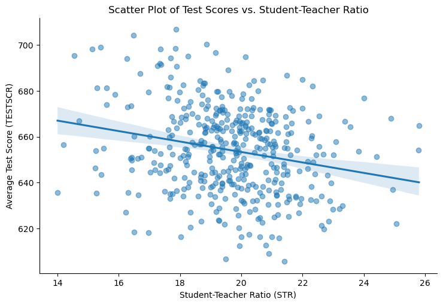

```
                            OLS Regression Results
==============================================================================
Dep. Variable:                testscr   R-squared:                       0.051
Model:                            OLS   Adj. R-squared:                  0.049
Method:                 Least Squares   F-statistic:                     22.58
Date:                Thu, 03 Oct 2024   Prob (F-statistic):           2.78e-06
Time:                        21:38:35   Log-Likelihood:                -1822.2
No. Observations:                 420   AIC:                             3648.
Df Residuals:                     418   BIC:                             3657.
Df Model:                           1
Covariance Type:            nonrobust
==============================================================================
                 coef    std err          t      P>|t|      [0.025      0.975]
------------------------------------------------------------------------------
Intercept    698.9330      9.467     73.825      0.000     680.323     717.543
str           -2.2798      0.480     -4.751      0.000      -3.223      -1.337
==============================================================================
Omnibus:                        5.390   Durbin-Watson:                   0.129
Prob(Omnibus):                  0.068   Jarque-Bera (JB):                3.589
Skew:                          -0.012   Prob(JB):                        0.166
Kurtosis:                       2.548   Cond. No.                         207.
==============================================================================

Notes:
[1] Standard Errors assume that the covariance matrix of the errors is correctly specified.
```

```python
correlation = df1['testscr'].corr(df1['str'])
print(f"Correlation between TESTSCR and STR: {correlation:.4f}")


sns.lmplot(x='str', y='testscr', data=df1, aspect=1.5, scatter_kws={'alpha':0.5})
plt.title('Scatter Plot of Test Scores vs. Student-Teacher Ratio')
plt.xlabel('Student-Teacher Ratio (STR)')
plt.ylabel('Average Test Score (TESTSCR)')
plt.show()

model = smf.ols('testscr ~ str', data=df1).fit()

print(model.summary())
```

ECON320 Python Programming Laboratory

Department of Economics

Emory University